# W3cubDocs

## Create your repo and workspace for Angular documentation

This section describes how to create the repo and the `git` workspace necessary to edit, test, and submit changes to the Angular documentation.

> **IMPORTANT**: Because `git` commands are not beginner friendly, the topics in this section include procedures that should reduce the chance of `git` mishaps. Fortunately, because you are working in your own account, even if you make a mistake, you can't harm any of the Angular code or documentation.

> To follow the procedures in these topics, you must use the repo and directory configuration presented in this topic. The procedures in these topics are designed to work with this configuration.

> If you use a different configuration, the procedures in these topics might not work as expected and you could lose some of your changes.

The code and documentation for the Angular framework are stored in a public repository, or repo, on github.com in the `angular` account. The path to the Angular repo is https://github.com/angular/angular, hence the abbreviated name, `angular/angular`.

[GitHub](https://github.com) is a cloud service that hosts many accounts and repositories. You can imagine the `angular/angular` repo in GitHub as shown in this image.

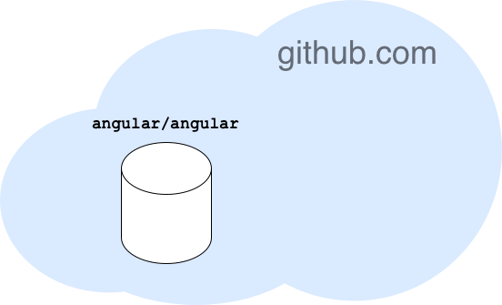

### Fork the `angular/angular` repo to your account

As a public repo, `angular/angular` is available for anyone to read and copy, but not to change. While only specific accounts have permission to make changes to `angular/angular`, anyone with a GitHub account can request a change to it. Change requests to `angular/angular` are called *pull requests*. A pull request is created by one account to ask another account to pull in a change.

Before you can open a pull request, you need a forked copy of `angular/angular` in your personal GitHub account.

To get a forked copy of `angular/angular`, you fork the `angular/angular` repo into your personal GitHub account and end up with the repos shown in the following image. From the perspective of `personal/angular`, `angular/angular` is the upstream repo and `personal/angular` is the origin repo.

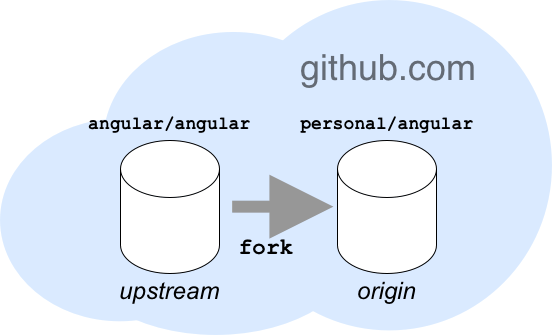

#### To fork the angular repo to your account

Perform this procedure in a browser.

1. Sign into your [GitHub](https://github.com) account. If you don't have a GitHub account, [create a new account](https://github.com/join) before you continue.
2. Navigate to [`https://github.com/angular/angular`](https://github.com/angular/angular).
3. In [`https://github.com/angular/angular`](https://github.com/angular/angular), click the **Fork** button near the top-right corner of the page. This image is from the top of the [`https://github.com/angular/angular`](https://github.com/angular/angular) page and shows the **Fork** button.

[figure not shown]

4. In **Create a new fork**:
   1. Accept the default values in **Owner** and **Repository name**.
   2. Confirm that **Copy the `main` branch only** is checked.
   3. Click **Create repository**. The forking process can take a few minutes.
5. You now have a copy of the `angular/angular` repo in your GitHub account.

After your fork of `angular/angular` is ready, your browser opens the web page of the forked repo in your GitHub account. In this image, notice that the account now shows the username of your personal GitHub account instead of the `angular` account.

[figure not shown]

As a forked repo, your new repo maintains a reference to `angular/angular`. From your account, `git` considers your `personal/angular` repo as the origin repo and `angular/angular` as the upstream repo. You can think of this as: your changes originate in the *origin* repo and you send them *upstream* to the `angular/angular` repo. The message below the repo name in your account, `forked from angular/angular`, contains a link back to the upstream repo.

This relationship comes into play later, such as when you update your `personal/angular` repo and when you open a pull request.

### Create a git workspace on your local computer

A `git` workspace on your local computer is where copies of GitHub repos in the cloud are stored on your local computer. To edit Angular documentation on your local computer, you need a clone of your origin repo, `personal/angular`.

Clone the `personal/angular` repo into the subdirectory for your account, as this illustration shows. Remember to replace `personal` with your GitHub username. The `personal/angular` directory in your workspace becomes your `working` directory. You do your editing in the working directory of your `personal/angular` repo.

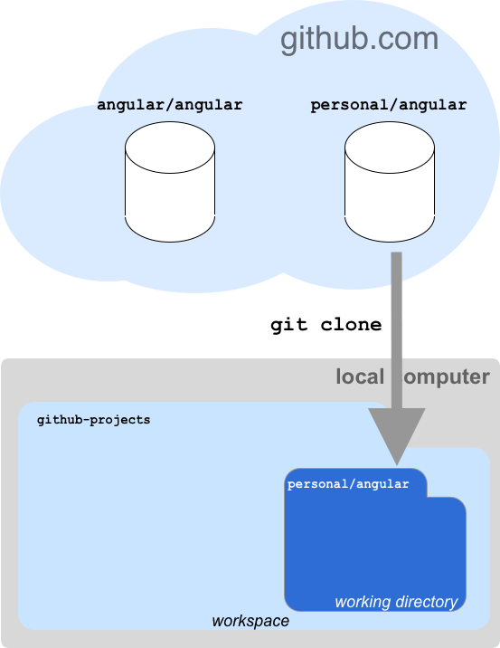

Cloning a repo duplicates the repo that's in the cloud on your local computer. There are procedures to keep the clone on your local computer in sync with the repo in the cloud that are described later.

#### To clone the Angular repo into your workspace

Perform these steps in a command-line tool on your local computer.

1. Navigate to the `workspace` directory. In this example, this is the directory named, `github-projects`.

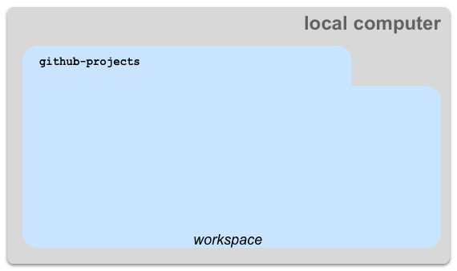

   If this directory isn't on your local computer, create it, and then navigate to it before you continue.
2. From the workspace directory, run this command to create a directory for the repo from your `personal` account Remember to replace `personal` with your GitHub username.

   ```
   mkdir personal
   ```

3. From the workspace directory, run this command to clone the origin `personal/angular` repo into the `personal` account directory. Remember to replace `personal` with your GitHub username.

   ```
   git clone https://github.com/personal/angular personal/angular
   ```

Your local computer is now configured as shown in the following illustration.

Your `working` directory is the `personal/angular` directory in your `git` workspace directory. This directory and its subdirectories have the files that you edit to fix documentation issues.

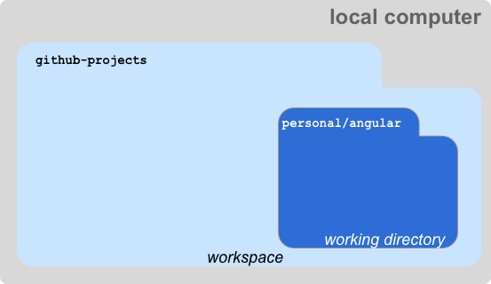

### Complete the software installation

After you clone the origin repo on your local computer, run these commands from a command-line tool:

1. Install the npm modules used by the Angular project. In a command line tool on your local computer:
   1. Navigate to your `git` workspace. In this example, this is the `github-projects` directory.
   2. In your `git` workspace, run this command to navigate to the documentation root directory in your clone of the `personal/angular` repo. Remember to replace `personal` with your GitHub username.

      ```
      cd personal/angular
      ```

   3. Run this command to install the Angular dependencies.

      ```
      yarn
      ```

   4. Run this command to navigate to the documentation project.

      ```
      cd aio
      ```

   5. Run this command to install the npm modules for the documentation.

      ```
      yarn
      ```

2. Locate `angular/aio/tools/doc-linter/vale.ini` in your working directory to use in the next step as the path to the configuration file in the **Vale:Config** setting.
3. [Install Vale](https://github.com/angular/angular/tree/main/aio/tools/doc-linter/README.md#install-vale-on-your-development-system) to complete the software installation.

## Build and test the Angular documentation

Angular provides tools to build and test the documentation. To review your work and before you submit your updates in a pull request, be sure to build, test, and verify your changes using these tools.

> Note that the instructions found in https://github.com/angular/angular/blob/main/docs/DEVELOPER.md are to build and test the Angular framework and not the Angular documentation.

> The procedures on this page build only the Angular documentation. You don't need to build the Angular framework to build the Angular documentation.

### To navigate to the Angular documentation directory

Perform these steps from a command-line tool on your local computer.

1. Navigate to the Angular documentation in the working directory of your account in your `git` workspace on your local computer.
2. Navigate to your `git` workspace directory. In this example, this is the `github-projects` directory.
   1. Run this command to navigate to the working directory with the `angular` repo you forked to your personal account. Remember to replace `personal` with your GitHub username.

      ```
      cd personal/angular
      ```

   2. Run this command to navigate to the Angular documentation directory.

      ```
      cd aio
      ```

The Angular documentation directory is the root of the Angular documentation files. These directories in the `angular/aio` directory are where you find the files that are edited the most.

| Directory | Files |
| --- | --- |
| `angular/aio/content` | Files and other assets used in the Angular documentation |
| `angular/aio/content/guide` | The markdown files for most Angular documentation |
| `angular/aio/content/tutorial` | The markdown files used by the Tour of Heroes tutorial |

The Angular documentation source has many other directories in `angular/aio` but they don't change often.

### To build and view the Angular documentation on your computer

Perform these steps from a command-line tool on your local computer.

1. Build the Angular documentation.
   1. From the Angular documentation directory, run this command:

      ```
      yarn build
      ```

   2. If building the documentation reports one or more errors, fix the errors and repeat the previous step before you continue.
2. Start the local documentation server.
   1. From the documentation directory, run this command:

      ```
      yarn start
      ```

   2. Open a browser on your local computer and view your documentation at `https://localhost:4200`.
3. Review the documentation in the browser.

### To run the automated tests on the Angular documentation

Perform these steps from a command-line tool on your local computer.

1. Navigate to the documentation directory, if you're not already there.
2. From the documentation directory, run this command to build the documentation before you test it:

   ```
   yarn build
   ```

3. If building the documentation returns one or more errors, fix those and build the documentation again before you continue.
4. From the documentation directory, run these commands to start the automated tests that verify the docs are consistent. These are most, but not all, of the tests that are performed after you open your pull request. Some tests can only be run in the automated testing environment.

   ```
   yarn e2e
   yarn docs-test
   ```

When you run these tests on your documentation updates, be sure to correct any errors before you open a pull request.

## Next steps

After you build the documentation from your forked repo on your local computer and the tests run without error, you are ready to continue.

You have successfully configured your local computer to edit Angular documentation and open pull requests.

Continue to the other topics in this section for information about how to perform other documentation tasks.

Last reviewed on Wed Oct 12 2022

© 2010–2023 Google, Inc.  
Licensed under the Creative Commons Attribution License 4.0.  
https://angular.io/guide/doc-prepare-to-edit